# Preprocesamiento (Volumen III)

Missing Values  
(Tips de Programación)  
Santiago Banchero  
Leo Lucianna  
Juan Manuel Fernandez

Minería de Datos - UBA

### Contenidos

Vamos a ver algunos tips para implementar las siguientes técnicas en R:

- Missing Values (Valores Faltantes)
  - Análisis de Faltantes
  - Registros completos
  - Imputaciones (Media, Regresiones, Hot deck)
  - Multiple Imputation by Chained Equations (MICE)
  - Análisis gráfico de los métodos de imputación

### Análisis de Faltantes

Cargamos iris y generamos datos faltantes aleatoriamente:

```r
for(i in 1:4) {
  for(j in 1:5) {
    inst.aleat<-sample(1:nrow(iris), 1, replace=F)
    iris[inst.aleat, i]<-NA
  }
}
```

Podemos ver, por ejemplo, las instancias con que poseen faltante en una variable:

```r
iris[is.na(iris$Sepal.Length),]
```

```
    Sepal.Length Sepal.Width Petal.Length Petal.Width    Species
27            NA         3.4          1.6         0.4     setosa
29            NA         3.4          1.4         0.2     setosa
39            NA         3.0          1.3         0.2     setosa
57            NA         3.3          4.7         1.6 versicolor
111           NA         3.2          5.1         2.0  virginica
```

### Análisis de Faltantes (++)

Podríamos contar la cantidad de faltantes para una variable:

```r
sum(is.na(iris$Sepal.Length))
```

```
[1] 5
```

También podemos analizar la proporción de faltantes sobre el total de instancias:

```r
round(sum(is.na(iris$Sepal.Length))/nrow(iris)*100,2)
```

```
[1] 3.33
```

### Valores Faltantes: Registros Completos

Si quisieramos trabajar únicamente con las instancias del dataset con registros completos:

```r
iris.reg_completos<-na.omit(iris)
nrow(iris.reg_completos)
```

```
[1] 131
```

Simplemente podemos realizar los cálculos removiendo los faltantes:

```r
print(mean(iris$Petal.Length))
```

```
[1] NA
```

```r
print(mean(iris$Petal.Length, na.rm = TRUE))
```

```
[1] 3.772414
```

### Valores Faltantes: Imputación por la Media

Seleccionamos las instancias con valor faltante y las reemplazamos por la media de ese atributo:

```r
# Sustitución por la media
iris.imp<-iris
iris.imp$media<-iris$Sepal.Length

iris.imp$media[is.na(iris.imp$media)]<-mean(iris.imp$media, na.rm = TRUE)

# Verificamos que no quedan faltantes
sum(is.na(iris.imp$media))
```

```
[1] 0
```

### Valores Faltantes: Imputación por Regresión

Primero ajustamos el modelo de Regresión:

```r
#Armamos el modelo
rl_model<-lm(iris.imp$Sepal.Length ~ iris.imp$Sepal.Width+iris.imp$Petal.Length, data = iris.imp)

# Imprimimos los coeficientes del modelo
print(rl_model$coefficients)
```

```
          (Intercept)  iris.imp$Sepal.Width iris.imp$Petal.Length
            2.3393697             0.5679857             0.4681732
```

Luego, con la instrucción summary tenemos un resumen con los coeficientes y la eficiencia del modelo ajustado, entre otras cosas

```r
summary(rl_model)
```

### Valores Faltantes: Imputación por Regresión (++)

Analizamos el modelo:

```
Call:
lm(formula = iris.imp$Sepal.Length ~ iris.imp$Sepal.Width + iris.imp$Petal.Length,
    data = iris.imp)

Residuals:
     Min       1Q   Median       3Q      Max
-0.96611 -0.23850 -0.00493  0.22746  0.65347

Coefficients:
                      Estimate Std. Error t value Pr(>|t|)
(Intercept)            2.33937    0.25496   9.176 7.52e-16 ***
iris.imp$Sepal.Width   0.56799    0.07155   7.939 7.54e-13 ***
iris.imp$Petal.Length  0.46817    0.01787  26.197  < 2e-16 ***
---
Signif. codes:  0 '***' 0.001 '**' 0.01 '*' 0.05 '.' 0.1 ' ' 1

Residual standard error: 0.3337 on 133 degrees of freedom
  (14 observations deleted due to missingness)
Multiple R-squared:  0.8394,    Adjusted R-squared:  0.837
F-statistic: 347.6 on 2 and 133 DF,  p-value: < 2.2e-16
```

### Valores Faltantes: Imputación por Regresión (+++)

Ahora, solo queda imputar los valores faltantes en función del modelo generado:

```r
# Imputamos en base al modelo
iris.imp$regresion<-iris.imp$Sepal.Length

SW<-iris.imp$Sepal.Width[is.na(iris.imp$Sepal.Length)]
PL<-iris.imp$Petal.Length[is.na(iris.imp$Sepal.Length)]
coef<-rl_model$coefficients

# Hacemos la imputación
iris.imp$regresion[is.na(iris.imp$regresion)]<-coef[1]+SW*coef[2]+PL*coef[3]

# Verificamos que no existen faltantes
sum(is.na(iris.imp$regresion))
```

```
[1] 0
```

### Valores Faltantes: Imputación Hot Deck

Para hot deck, vamos a utilizar la librería VIM. La función hotdeck imputará los datos directamente sobre el atributo del parámetro y generará un nuevo atributo -boolean- que indica las instancias imputadas:

```r
# Cargamos la librería
library(VIM)

# Definimos un dataframe auxiliar para no perder la variable original
df_aux<-hotdeck(iris, variable="Sepal.Length")
iris.imp$hotdeck<-df_aux$Sepal.Length
iris.imp$hotdeckbool<-df_aux$Sepal.Length_imp

# Verificamos que no existen faltantes
sum(is.na(iris.imp$hotdeck))
```

```
[1] 0
```

### Multiple Imputation by Chained Equations (MICE)

Vamos a trabajar con MICE, esta librería provee un gráfico que detalla la cantidad de atributos con missing por cada atributo:

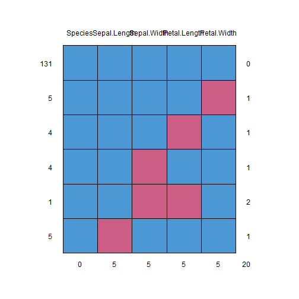

```
    Species Sepal.Length Sepal.Width Petal.Length Petal.Width
131       1            1           1            1           1  0
5         1            1           1            1           0  1
4         1            1           1            0           1  1
4         1            1           0            1           1  1
1         1            1           0            0           1  2
5         1            0           1            1           1  1
          0            5           5            5           5 20
```

```r
# Cargamos la librería
library(mice)
# Gráfico con el resumen de los missing para el dataset iris
md.pattern(iris)
```

### MICE (++)

Ahora avanzamos sobre la imputación:

```r
# Imputamos los datos con pmm (media, para valores numéricos)
imputed_Data <- mice(iris, m=5, maxit = 3, method = 'pmm', seed = 500)
```

### MICE (++)

Ahora, con la función complete recuperamos los datos completos:

```r
#Tomamos los datos completos
completeData <- complete(imputed_Data)

# Los asignamos a una nueva variable
iris.imp$mice <- completeData$Sepal.Length

# Verificamos que no existen faltantes
sum(is.na(iris.imp$mice))
```

```
[1] 0
```

### Análisis Gráfico de los métodos de imputación

Ahora, analizamos gráficamente la distribución original y su variación luego de realizar las imputaciones:

```r
# Quitamos los atributos que no vamos a usar y renombramos Sepal.Length
iris.imp<-iris.imp[,-c(2:5)]
names(iris.imp)[1]<-"original"

# Analisis grafico de los resultados
plot(density(iris.imp$original, na.rm=TRUE), type = "l", col="red", ylab = "Original", ylim=c(0,0.5))
lines(density(iris.imp$media, na.rm=TRUE), type = "l", col="blue")
lines(density(iris.imp$regresion, na.rm=TRUE), type = "l", col="green")
lines(density(iris.imp$hotdeck, na.rm=TRUE), type = "l", col="yellow")
lines(density(iris.imp$mice, na.rm=TRUE), type = "l", col="black")
legend(7, 0.5, legend=c("Original", "Media", 'Regresión', 'Hotdeck', 'MICE'), col=c("red", "blue", 'green','yellow', "black"), lty=1, cex=0.8)
```

### Análisis Gráfico de los métodos de imputación (++)

Obtenemos los siguientes gráficos de densidad:

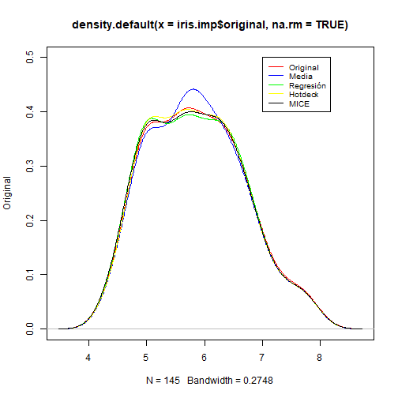